# Practical Machine Learning Course Project

nigusseba

April 24, 2016

## Synopsis

This report describes the data partitioning, preprocessing, building and cross-validating the model. Since this is a classification problem, *Random Forest* algorithm selected and is believed to be very accurate and reliable model for wider range of classification applications. The accuracy of the fit model over the training data set found out to be 100% using 54 predictor variables. Final model fit has OOB estimated error rate of about 0.15%. The model also cross-validated using a separate deta set and the out-of-sample estimated error rate was 0.18%.

## Background

Using devices such as Jawbone Up, Nike FuelBand, and Fitbit it is now possible to collect a large amount of data about personal activity relatively inexpensively. These type of devices are part of the quantified self movement – a group of enthusiasts who take measurements about themselves regularly to improve their health, to find patterns in their behavior, or because they are tech geeks. One thing that people regularly do is quantify how much of a particular activity they do, but they rarely quantify how well they do it. In this project, your goal will be to use data from accelerometers on the belt, forearm, arm, and dumbell of 6 participants. They were asked to perform barbell lifts correctly and incorrectly in 5 different ways. More information is available from the website here: http://groupware.les.inf.puc-rio.br/har (see the section on the Weight Lifting Exercise Dataset).

## Tiding and PreProcessing Data

The training and testing datasets were downloaded and cleaned. The cleaning removes variables with missing and blank observations.

```r
trainingRaw <- read.csv(trainingFile, sep=",", header = TRUE)
dim(trainingRaw)
```

[1] 19622 160

```r
testingRaw <- read.csv(testingFile, sep=",", header = TRUE)
dim(testingRaw)
```

[1] 20 160

The total number of variables with either missing data or blank observations was 100. The variables from accelerometers on the *belt*, *forearm*, *arm*, and *dumbell* were selected as predictors for the analysis. Variables selected as predictors were:

```r
predictorVariables
```

```
 [1] "raw_timestamp_part_1" "raw_timestamp_part_2" "roll_belt"
 [4] "pitch_belt"           "yaw_belt"             "total_accel_belt"
 [7] "gyros_belt_x"         "gyros_belt_y"         "gyros_belt_z"
[10] "accel_belt_x"         "accel_belt_y"         "accel_belt_z"
[13] "magnet_belt_x"        "magnet_belt_y"        "magnet_belt_z"
[16] "roll_arm"             "pitch_arm"            "yaw_arm"
[19] "total_accel_arm"      "gyros_arm_x"          "gyros_arm_y"
[22] "gyros_arm_z"          "accel_arm_x"          "accel_arm_y"
[25] "accel_arm_z"          "magnet_arm_x"         "magnet_arm_y"
[28] "magnet_arm_z"         "roll_dumbbell"        "pitch_dumbbell"
[31] "yaw_dumbbell"         "total_accel_dumbbell" "gyros_dumbbell_x"
[34] "gyros_dumbbell_y"     "gyros_dumbbell_z"     "accel_dumbbell_x"
[37] "accel_dumbbell_y"     "accel_dumbbell_z"     "magnet_dumbbell_x"
[40] "magnet_dumbbell_y"    "magnet_dumbbell_z"    "roll_forearm"
[43] "pitch_forearm"        "yaw_forearm"          "total_accel_forearm"
[46] "gyros_forearm_x"      "gyros_forearm_y"      "gyros_forearm_z"
[49] "accel_forearm_x"      "accel_forearm_y"      "accel_forearm_z"
[52] "magnet_forearm_x"     "magnet_forearm_y"     "magnet_forearm_z"
```

The traning data set containing clean 54 predictor variables and a reponse variable. There are 19622 observations in the training data set.

### Partitioning Data

The training data was spartitionined for training and cross-validating. The *caret* package was used for training the model. Even though *Random Forest* implicitly creates random sample for cross-validation internally, here the training data was partitioned into training and cross-validating data set with 75% and 25% proportions, respectively. The cross-validation data set was used to estimate the out-of-smaple error rate and comapred it to the unbiased OOB estimated error rate of the *Random Forest* algorithm, estimated internally during building the model. Otherwise, random forests, does not need for cross-validation or a separate test set to get an unbiased estimate of the test set error (www.stat.berkeley.edu/~breiman/RandomForests/cc_home.htm#ooberr).

```r
suppressMessages(library(caret))
```

### Preprocessing Data

*Tiding training data set predictors:*

```r
trainData_pred <- trainData[, predictorVariables]
```

*Tiding cross-validation data set predictors:*

```r
crossVData_pred <- crossVData[, predictorVariables]
```

#### Selected Training Data Set

```r
trainData_T <- data.frame(trainData_pred, classe = trainData[, 55])
dim(trainData_T)
```

[1] 14718 55

*Checking for near zero variance of the tidy training data set:*

```r
TnearZVar <- nearZeroVar(trainData_T, saveMetrics=TRUE)
if (any(TnearZVar$nzv)) TnearZVar else message("No co-variates to eliminate")
```

#### Selected Cross-Validation Data Set

```r
crossVData_T <- data.frame(crossVData_pred, classe = crossVData[, 55])
dim(crossVData_T)
```

[1] 4904 55

### Building Random Forest Model

Random forest method was used as prediction algorithm and the model was built using the training data set, *trainData_T*. The In-Sample error was estimated using the training data set.

*The control parameters set up for model training:*

```r
ctrl <- trainControl(method="cv", number=3, verboseIter=F)
```

*Random Forest model was fit over the training data set:*

```r
suppressMessages(library(randomForest))
modelFit <- train(classe ~ ., data=trainData_T, method='rf', trControl=ctrl)
```

```
Random Forest

14718 samples
   54 predictor
    5 classes: 'A', 'B', 'C', 'D', 'E'

No pre-processing
Resampling: Cross-Validated (3 fold)
Summary of sample sizes: 9813, 9811, 9812
Resampling results across tuning parameters:

  mtry  Accuracy   Kappa
   2    0.9925941  0.9906315
  28    0.9964669  0.9955310
  54    0.9943605  0.9928656

Accuracy was used to select the optimal model using  the largest value.
The final value used for the model was mtry = 28.
```

```r
training_Res <- predict(modelFit, trainData_T)
confusionMatrix(training_Res, trainData[, 55])
```

```
Confusion Matrix and Statistics

          Reference
Prediction    A    B    C    D    E
         A 4185    0    0    0    0
         B    0 2848    0    0    0
         C    0    0 2567    0    0
         D    0    0    0 2412    0
         E    0    0    0    0 2706

Overall Statistics

               Accuracy : 1
                 95% CI : (0.9997, 1)
    No Information Rate : 0.2843
    P-Value [Acc > NIR] : < 2.2e-16

                  Kappa : 1
 Mcnemar's Test P-Value : NA

Statistics by Class:

                     Class: A Class: B Class: C Class: D Class: E
Sensitivity            1.0000   1.0000   1.0000   1.0000   1.0000
Specificity            1.0000   1.0000   1.0000   1.0000   1.0000
Pos Pred Value         1.0000   1.0000   1.0000   1.0000   1.0000
Neg Pred Value         1.0000   1.0000   1.0000   1.0000   1.0000
Prevalence             0.2843   0.1935   0.1744   0.1639   0.1839
Detection Rate         0.2843   0.1935   0.1744   0.1639   0.1839
Detection Prevalence   0.2843   0.1935   0.1744   0.1639   0.1839
Balanced Accuracy      1.0000   1.0000   1.0000   1.0000   1.0000
```

*The model accuracy over the training data set:*

```r
TrainM_accu <- postResample(training_Res, trainData_T$classe)
Tmodel_accu <- round(TrainM_accu[[1]]*100, 2)
Tmodel_accu
```

```
[1] 100
```

*Summary of the out-of-sample data test accuracy:*

```r
crossVData_Res <- predict(modelFit, crossVData_T)
CVM_accu <- postResample(crossVData_Res, crossVData_T$classe)
CVmodel_accu <- round(CVM_accu[[1]]*100, 2)
CVmodel_accu
```

```
[1] 99.82
```

Then cross-validation of the prediction model was performed using the cross-validation data set, *crossVData_T*. The overall accuracy of the model prediction using out of sample data was 99.82%, which is slightly lower than the training (in-sample) data set accuracy of 100%, as expected.

*Cross-validation result plot:*

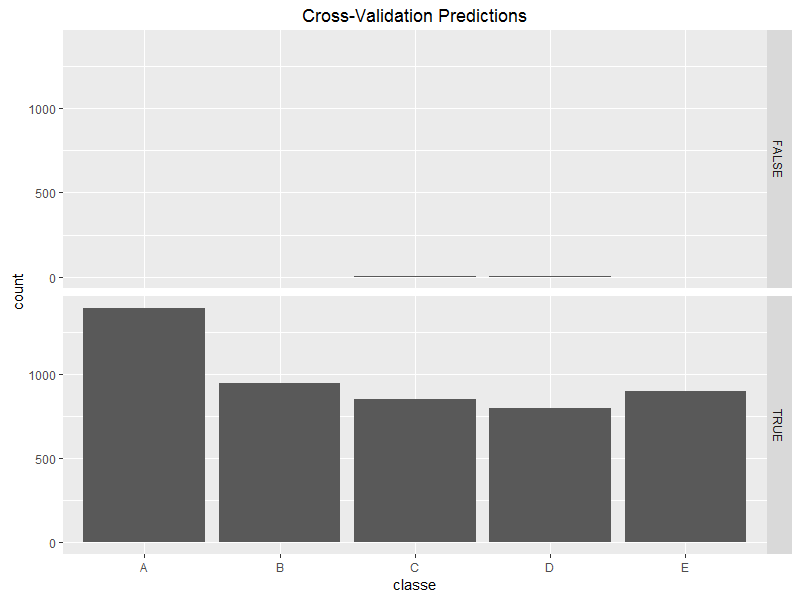

```r
suppressMessages(library(ggplot2))
crossVData_T$predRight <- crossVData_Res==crossVData_T$classe
qplot(classe, data=crossVData_T, main="Cross-Validation Predictions") + facet_grid(predRight ~ .)
```

### Final Model Tuning

Since *Random Forest* algorithm does not require separate data set for cross-validation, the selected model was tuned using the full set of the tidy trianing data set, *training*. The unbiased OOB estimated error rate of the model fitted over the whole tidy traning data set was 0.15%. The OOB estimated error rate is consistent with the cross-validation accuracy of 0.18% obtained using the cross-validation partitioned data set *crossVData_T*.

*Random Forst model training over the entire training data set*

```r
set.seed(8302014)
modelFit <- train(classe ~ ., data=training, method='rf', trControl=ctrl)
```

*#Summary of the Random Forest Algorithm fit over the entire training data set:*

```r
modelFit$finalModel
```

```
Call:
 randomForest(x = x, y = y, mtry = param$mtry)
               Type of random forest: classification
                     Number of trees: 500
No. of variables tried at each split: 28

        OOB estimate of  error rate: 0.15%
Confusion matrix:
     A    B    C    D    E  class.error
A 5578    2    0    0    0 0.0003584229
B    6 3789    2    0    0 0.0021069265
C    0    6 3414    2    0 0.0023378141
D    0    0    7 3206    3 0.0031094527
E    0    0    0    1 3606 0.0002772387
```

Since the OOB estimated error rate of the final optimal selected model is 0.15%, it is sufficiently accurate for this classification problem. This model does not need any further refinement or comparison with other model fitting algorithm. Hence the final optimal Random Forest model fit was used to evaluate the 20 test cases whose results are summarized in the next section.

## Final Model Results

The final optimal classification model selected using the Random Forest algorithm was used to rank important predictor variables and the top 20 most important predictor variables ranked by the Random Forst classification fit model are shown below:

```
rf variable importance

  only 20 most important variables shown (out of 54)

                     Overall
raw_timestamp_part_1 100.000
roll_belt             39.840
pitch_forearm         24.572
magnet_dumbbell_z     18.006
yaw_belt              17.642
magnet_dumbbell_y     16.199
pitch_belt            15.073
roll_forearm          14.990
accel_dumbbell_y       7.451
roll_dumbbell          5.809
accel_forearm_x        5.798
magnet_dumbbell_x      5.775
magnet_belt_y          5.513
accel_belt_z           5.283
total_accel_dumbbell   5.081
accel_dumbbell_z       4.841
magnet_belt_z          4.501
gyros_belt_z           3.921
yaw_dumbbell           3.547
magnet_forearm_z       3.391
```

### Model Evaluation

Predicted the outcome variable (classe) using the final model selected for the 20 different test cases in the data set, *testing*. The variable *pred20Test* holds the predicted outcome for the test database. The predicted outcome, *problem_id* and *user_name* variables are presented in tabular form below.

```
   pred20Test user_name   cvtd_timestamp problem_id
1           B     pedro 05/12/2011 14:23          1
2           A    jeremy 30/11/2011 17:11          2
3           B    jeremy 30/11/2011 17:11          3
4           A    adelmo 02/12/2011 13:33          4
5           A    eurico 28/11/2011 14:13          5
6           E    jeremy 30/11/2011 17:12          6
7           D    jeremy 30/11/2011 17:12          7
8           B    jeremy 30/11/2011 17:11          8
9           A  carlitos 05/12/2011 11:24          9
10          A   charles 02/12/2011 14:57         10
11          B  carlitos 05/12/2011 11:24         11
12          C    jeremy 30/11/2011 17:11         12
13          B    eurico 28/11/2011 14:14         13
14          A    jeremy 30/11/2011 17:10         14
15          E    jeremy 30/11/2011 17:12         15
16          E    eurico 28/11/2011 14:15         16
17          A     pedro 05/12/2011 14:22         17
18          B  carlitos 05/12/2011 11:24         18
19          B     pedro 05/12/2011 14:23         19
20          B    eurico 28/11/2011 14:14         20
```